# Tabular Data Foundations

### Fit straight line to points

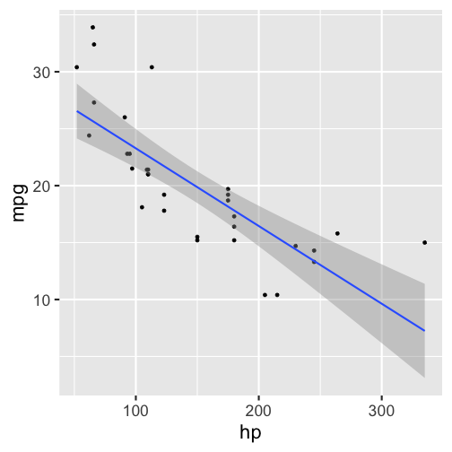

```r
> ggplot(mtc, aes(hp, mpg)) +
+   geom_point() +
+   geom_smooth(method="lm")
`geom_smooth()` using formula 'y ~ x'
```

- `"lm"` means “linear model,” which is a least-squares regression line.
- The gray band is the confidence interval.

### Fit smooth line to points

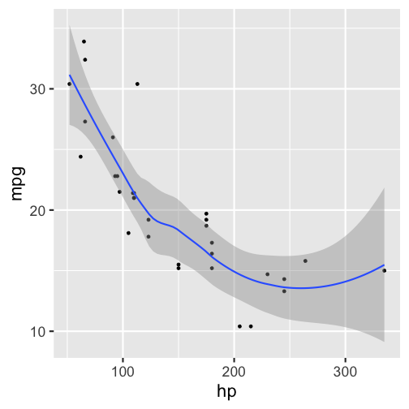

```r
> ggplot(mtc, aes(hp, mpg)) +
+   geom_point() +
+   geom_smooth(method="loess")
`geom_smooth()` using formula 'y ~ x'
```

- “loess” fits a collection of tiny regression lines, then glues them together.
- This is a better approximation than a straight line for these data.

### Fit smooth line to points without standard error

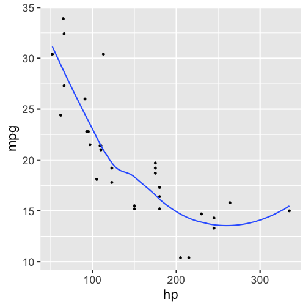

```r
> mtc %>% # with the pipe
+ ggplot(aes(hp, mpg)) +
+   geom_point() +
+   geom_smooth(method="loess", se=FALSE)
`geom_smooth()` using formula 'y ~ x'
```

- `se = FALSE` means do not plot the confidence band (using the standard error)

### Plotting categorical variables

- `gender` is a discrete variable, with two values.

```r
> data1 %>%
+   group_by(gender) %>%
+   summarize(mean_age=mean(age), mean_weight=mean(weight)) %>%
+ ggplot(aes(gender, mean_weight)) +
+   geom_col()
Error in group_by(., gender): object 'data1' not found
```

[output not shown]

### The grammar of graphics

- Most graphics systems are a large collection of functions to call to construct a graph piece by piece.
- `ggplot2` is different, and is based on the idea of a “grammar of graphics,” a set of primitives and rules for combining them in a way that makes sense for plotting data.
- This perspective is quite powerful, but requires learning a bit of vocabulary and a new way of thinking about graphics.

### The ggplot2 model (simplified version)

1. supply data frame (rows of observations, columns of variables)
2. use `aes` to map from variables (columns in data frame) to aethetics (visual properties of the plot): x, y, color, size, shape, and others.
3. choose a `geom`. This determines the type of the plot: point (a scatterplot), line (line graph or line chart), bar (barplot), and others.
4. choose a `stat` (statistical transformation): often `identity` (do no transformation), but can be used to count, bin, or summarize data (e.g., in a histogram).
5. choose a `scale`. This converts from the units used in the data frame to the units used for display.
6. provide optional facet specification.

### ggplot2 cheatsheet

[figure not shown]